# Exploration of tidymodels in RStudio

Ugo Iroh

2023-02-02

For my Final Assignment, I decided to explore `tidymodels` because I wanted to delve deeper into data structures within the `tidyverse`. I have already been able to create a couple tables, graphs, and plots, and done analyses using the coding skills that I have developed over the duration of the course, with a particular focus on the skills that I learned in the Entering the Tidyverse lecture. With the troubleshooting help of some great R resources (linked below), I was able to undertake a data analysis project in which I analyzed a data set about sea urchins, taken from a life science journal. I was also keen on exploring the `tidyverse` because it contains a lot of helpful functional programming tools, particularly data manipulation tools, that I wanted to try my hand at.

`tidymodels` is an R “meta-package” that allows users to model and analyze statistics within the design philosophy, grammar, and data structures of the `tidyverse`. It includes a core set of packages, such as `broom`, `ggplot2`, and `purr`. In this project, I mainly utilized `ggplot2`.

This HTML file will serve as a comprehensive guide as to how I completed my project, along with notes, statistical analyses, and graphs. :)

1. The first thing I had to do was make sure that `tidymodels` was downloaded. I hit `install.packages("tidymodels")` in the console. I had already installed the `tidyverse` in a previous lecture, so that particular step was fairly straightforward. To download, hit `install.packages("tidyverse")`in the console. I also installed `modeldata`, which contains data sets used in documentation and testing for `tidymodels`.
- In the following example, I will be going over modeling with `tidymodels` in R. I will also be annotating with my notes when necessary. I decided to use an online data set for my project, though I recognize that built-in data sets are a bit more accessible.

`Example 1`

I am presented with data from [Constable (1993)](https://link.springer.com/article/10.1007/BF00349318), in which I am considering categorical data (treatment) and continuous data (width of sea urchins).

**Question: Is there a statistically significant relationship between Treatment and Sea Urchin Width?**

```r
### Load packages
library(tidyverse)
library(tidymodels)
### Load and view the data
urchin_data <- read.table(file="Data/urchins.csv", header=T, sep=',')
View(urchin_data)
anyNA(urchin_data) #sees if NAs are present
```

```
## [1] FALSE
```

```r
### Clean the data
urchin_data2 <- urchin_data[rowSums(is.na(urchin_data)) != ncol(urchin_data), ] #removes NAs in all rows
print(urchin_data2)
```

```
##      TREAT   IV  SUTW
## 1  Initial  3.5 0.010
## 2  Initial  5.0 0.020
## 3  Initial  8.0 0.061
## 4  Initial 10.0 0.051
## 5  Initial 13.0 0.041
## 6  Initial 13.0 0.061
## 7  Initial 15.0 0.041
## 8  Initial 15.0 0.071
## 9  Initial 16.0 0.092
## 10 Initial 17.0 0.051
## 11 Initial 19.0 0.051
## 12 Initial 20.0 0.082
## 13 Initial 21.0 0.102
## 14 Initial 21.0 0.092
```

[output cut: 58 more lines]

I also want to clean the data because the data set is divided into three columns: TREAT, IV, and SUTW. I don’t entirely think this is conducive to the naming system I will be using later on. So, let’s change it!

I will be using the `setNames` function to set the new names of the columns. It follows the order: `setNames(x, c("name1", "name2", "name3"))`. For more documentation, [click here](https://www.rdocumentation.org/packages/stats/versions/3.6.2/topics/setNames).

```r
urchin_data2 <- setNames(urchin_data2, c("Treatment", "Initial_Volume", "Sea_Urchin_Width"))  #code to change names
```

I want to categorize and represent the categorical data (Treatment) by storing it on multiple levels. The `factor` function is also extremely useful!

```r
urchin_data2$Treatment <- factor(urchin_data2$Treatment, levels = c("Initial", "Low", "High"))
```

Next, I would like to visualize my data using `ggplot2` under the `tidymodels` package. I wanted to modify some components of my graph, so I looked onto the [ggplot](https://ggplot2.tidyverse.org/reference/theme.html) website, where I was able to find some interesting ways to spice up my graph.

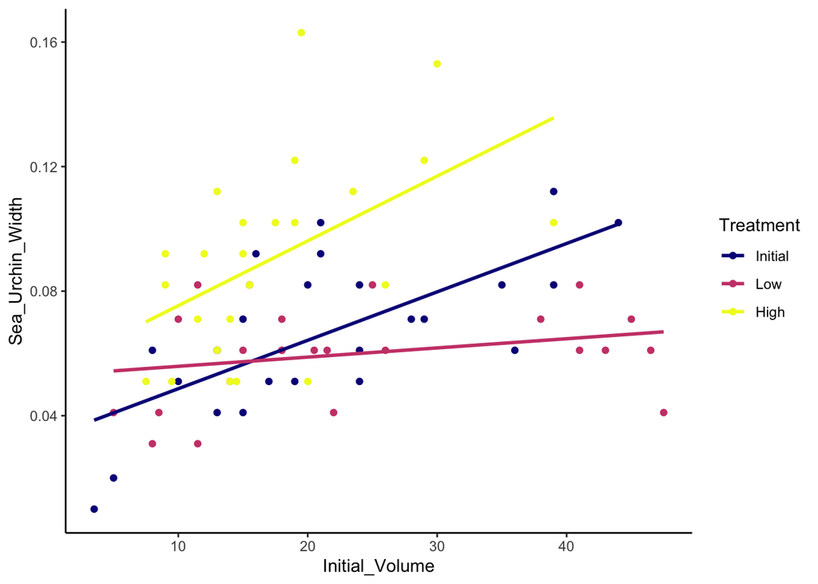

```r
ggplot(urchin_data2, aes(x=Initial_Volume , y=Sea_Urchin_Width, group=Treatment, col=Treatment)) +
  geom_point() + geom_smooth(method=lm, se = F) + scale_colour_viridis_d(option = "C") + theme_bw() + theme(panel.border = element_blank(), panel.grid.major = element_blank(),
panel.grid.minor = element_blank(), axis.line = element_line(colour = "black"))
```

I will be analyzing the relationship between a categorical variable (Treatments) and a continuous variable (Sea_Urchin_Width). Thus, I need to do an ANOVA analysis to see if the treatments and sea urchin width variables are statistically significant. More information on ANOVA in the Data Analysis in R lecture on January 30th. I also utilized [this website](https://www.scribbr.com/statistics/anova-in-r/), which really helped me to differentiate between one-way and two-way ANOVA analyses.

I also noticed that the slopes of the treatments are different, with two crossing slopes/lines of regression representing initial and low treatments. For this reason, I need to create some functions that allow for **two-way interactions**. I initially didn’t know how to go about creating a formula for two-way interactions. There’s some helpful resources that I used, such as Stack Overflow here: https://stackoverflow.com/questions/71797366/model-simplification-two-way-anova.

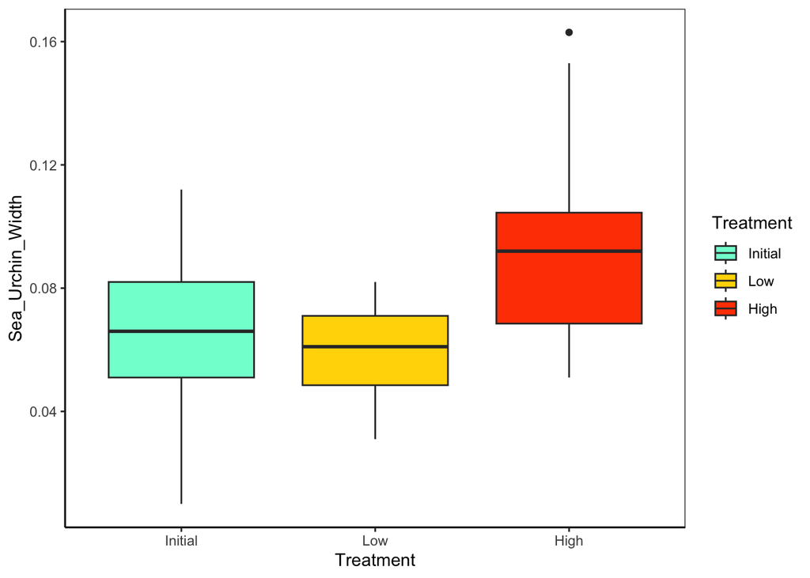

```r
#Remember: yVar~xVar
#Sea_Urchin_Width ~ Initial_Volume * Treatment
               #or
#Sea_Urchin_Width ~ Initial_Volume:Treatment

### Plotting the data
urchinplot <- ggplot(urchin_data2, aes(x=Treatment , y=Sea_Urchin_Width, group=Treatment, fill=Treatment)) +
  geom_boxplot() + theme_bw() + theme(panel.grid.major = element_blank(), panel.grid.minor = element_blank(),
panel.background = element_blank(), axis.line = element_line(colour = "black")) + (scale_fill_manual(values = c("aquamarine", "gold", "orangered")))
print(urchinplot) #I made a basic plot of the data set in which I compare Treatment and Sea Urchin Width
```

```r
### ANOVA analyses
aovTrt<-aov(Sea_Urchin_Width ~ Treatment, data=urchin_data2)
summary(aovTrt) #ANOVA analysis of Sea Urchin Width and Treatment. The aov function doesn't specify where the significance is, however, this is a start to doing the ANOVA analyses.
```

```
##             Df  Sum Sq  Mean Sq F value   Pr(>F)
## Treatment    2 0.01238 0.006190   10.04 0.000149 ***
## Residuals   69 0.04254 0.000617
## ---
## Signif. codes:  0 '***' 0.001 '**' 0.01 '*' 0.05 '.' 0.1 ' ' 1
```

```r
TukeyHSD(aovTrt) #The Tukey HSD test allows for all possible pairwise comparisons; it is another way of performing statistical analysis.
```

```
##   Tukey multiple comparisons of means
##     95% family-wise confidence level
##
## Fit: aov(formula = Sea_Urchin_Width ~ Treatment, data = urchin_data2)
##
## $Treatment
##                      diff          lwr        upr     p adj
## Low-Initial  -0.006791667 -0.023960852 0.01037752 0.6122986
## High-Initial  0.023791667  0.006622481 0.04096085 0.0040756
## High-Low      0.030583333  0.013414148 0.04775252 0.0001813
```

```r
aovTrt2 <- aov(Sea_Urchin_Width ~ Treatment*Initial_Volume, data=urchin_data2)
summary(aovTrt2) #ANOVA analysis of Sea Urchin Width and Treatment and Initial Volume. There is an interaction between Treatment and Initial Volume based on the initial boxplot.
```

```
##                          Df   Sum Sq  Mean Sq F value   Pr(>F)
## Treatment                 2 0.012380 0.006190  13.832 9.62e-06 ***
## Initial_Volume            1 0.008396 0.008396  18.762 5.15e-05 ***
## Treatment:Initial_Volume  2 0.004609 0.002304   5.149  0.00835 **
## Residuals                66 0.029536 0.000448
## ---
## Signif. codes:  0 '***' 0.001 '**' 0.01 '*' 0.05 '.' 0.1 ' ' 1
```

```r
### Linear model regression
#I wanted to try doing linear regression models based on different interactions and to see which groups would be significant, less significant, or not significant.

lmTrt <- lm(Sea_Urchin_Width ~ Initial_Volume, data=urchin_data2)
summary(lmTrt) #not so significant
```

```
##
## Call:
## lm(formula = Sea_Urchin_Width ~ Initial_Volume, data = urchin_data2)
##
## Residuals:
##       Min        1Q    Median        3Q       Max
## -0.050962 -0.017614 -0.006124  0.016195  0.091532
##
## Coefficients:
##                 Estimate Std. Error t value Pr(>|t|)
## (Intercept)    0.0586643  0.0067191   8.731 8.24e-13 ***
## Initial_Volume 0.0006566  0.0002834   2.317   0.0235 *
## ---
## Signif. codes:  0 '***' 0.001 '**' 0.01 '*' 0.05 '.' 0.1 ' ' 1
##
## Residual standard error: 0.02699 on 70 degrees of freedom
## Multiple R-squared:  0.07121,    Adjusted R-squared:  0.05794
## F-statistic: 5.367 on 1 and 70 DF,  p-value: 0.02345
```

```r
lmTrt2 <- lm(Sea_Urchin_Width ~ Initial_Volume + Treatment, data=urchin_data2)
summary(lmTrt2) #more significant
```

```
##
## Call:
## lm(formula = Sea_Urchin_Width ~ Initial_Volume + Treatment, data = urchin_data2)
##
## Residuals:
##       Min        1Q    Median        3Q       Max
## -0.042448 -0.016374 -0.000312  0.012964  0.070312
##
## Coefficients:
##                  Estimate Std. Error t value Pr(>|t|)
## (Intercept)     0.0453030  0.0069515   6.517 1.04e-08 ***
## Initial_Volume  0.0009908  0.0002423   4.089 0.000117 ***
## TreatmentLow   -0.0089178  0.0064895  -1.374 0.173901
## TreatmentHigh   0.0280645  0.0065525   4.283 5.93e-05 ***
## ---
## Signif. codes:  0 '***' 0.001 '**' 0.01 '*' 0.05 '.' 0.1 ' ' 1
##
## Residual standard error: 0.02241 on 68 degrees of freedom
## Multiple R-squared:  0.3783, Adjusted R-squared:  0.3509
## F-statistic: 13.79 on 3 and 68 DF,  p-value: 4.014e-07
```

```r
lmTrt3 <- lm(Sea_Urchin_Width ~ Initial_Volume + Treatment + Initial_Volume*Treatment, data=urchin_data2)
summary(lmTrt3) #very significant given the Treatment variable
```

```
##
## Call:
## lm(formula = Sea_Urchin_Width ~ Initial_Volume + Treatment +
##     Initial_Volume * Treatment, data = urchin_data2)
##
## Residuals:
##       Min        1Q    Median        3Q       Max
## -0.045133 -0.013639  0.001111  0.013226  0.067907
##
## Coefficients:
##                                Estimate Std. Error t value Pr(>|t|)
## (Intercept)                   0.0331216  0.0096186   3.443 0.001002 **
## Initial_Volume                0.0015546  0.0003978   3.908 0.000222 ***
## TreatmentLow                  0.0197824  0.0129883   1.523 0.132514
## TreatmentHigh                 0.0214111  0.0145318   1.473 0.145397
## Initial_Volume:TreatmentLow  -0.0012594  0.0005102  -2.469 0.016164 *
## Initial_Volume:TreatmentHigh  0.0005254  0.0007020   0.748 0.456836
## ---
## Signif. codes:  0 '***' 0.001 '**' 0.01 '*' 0.05 '.' 0.1 ' ' 1
##
## Residual standard error: 0.02115 on 66 degrees of freedom
## Multiple R-squared:  0.4622, Adjusted R-squared:  0.4215
## F-statistic: 11.35 on 5 and 66 DF,  p-value: 6.424e-08
```

```r
### Using logLike
#logLike uses the likelihood method as a measure of how well a particular model fits the data

logLik(lmTrt) #158.9229 (df=3)
```

```
## 'log Lik.' 158.9229 (df=3)
```

```r
logLik(lmTrt2) #173.3739 (df=5).
```

```
## 'log Lik.' 173.3739 (df=5)
```

```r
logLik(lmTrt3) #178.5939 (df=7)
```

```
## 'log Lik.' 178.5939 (df=7)
```

```r
logLik(aovTrt) #165.4589 (df=4)
```

```
## 'log Lik.' 165.4589 (df=4)
```

```r
logLik(aovTrt2) #178.5939 (df=7)
```

```
## 'log Lik.' 178.5939 (df=7)
```

**Interpretation of Statistical Analyses**

`logLik(aovTrt2)` and `logLik(lmTrt3)` have the highest (and the same) loglikelihood values, meaning that they may offer the best fit to the data set. I will perform model comparisons to visualize the data.

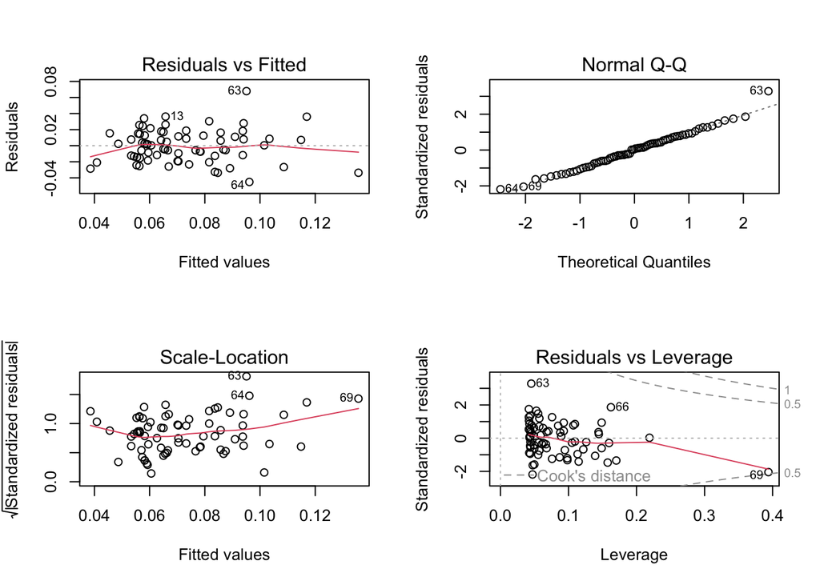

```r
### Model comparisons

aovTrt2 <- aov(Sea_Urchin_Width ~ Treatment*Initial_Volume, data=urchin_data2)
par(mfrow=c(2,2)) #The mfrow() parameter allows to split the screen in several panels
plot(aovTrt2)
```

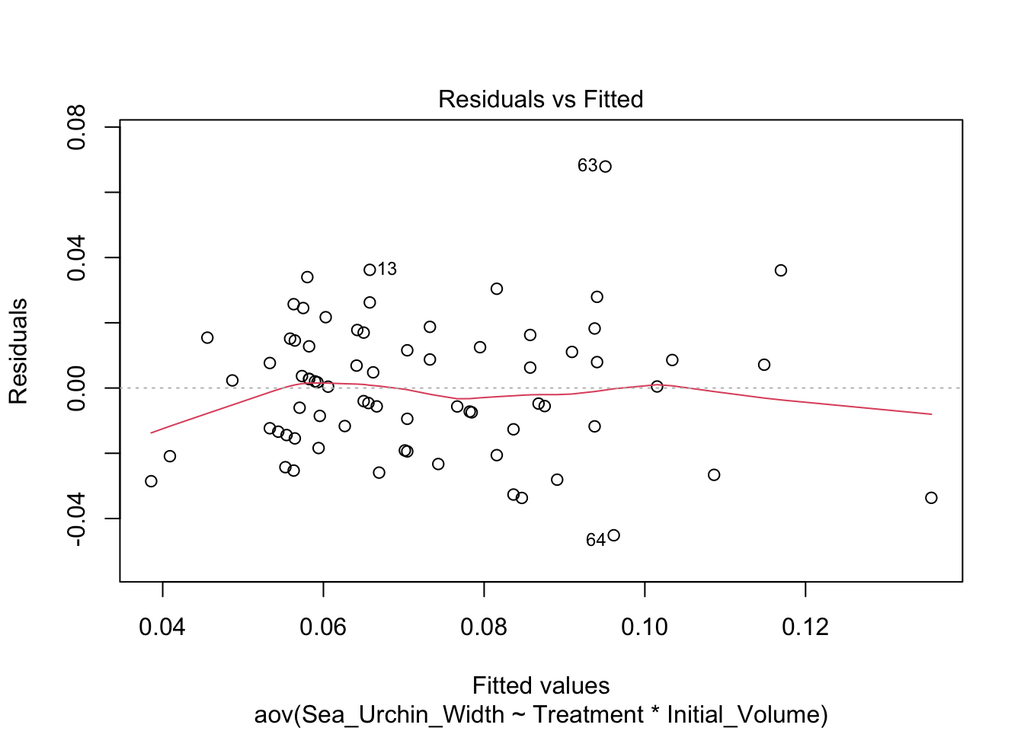

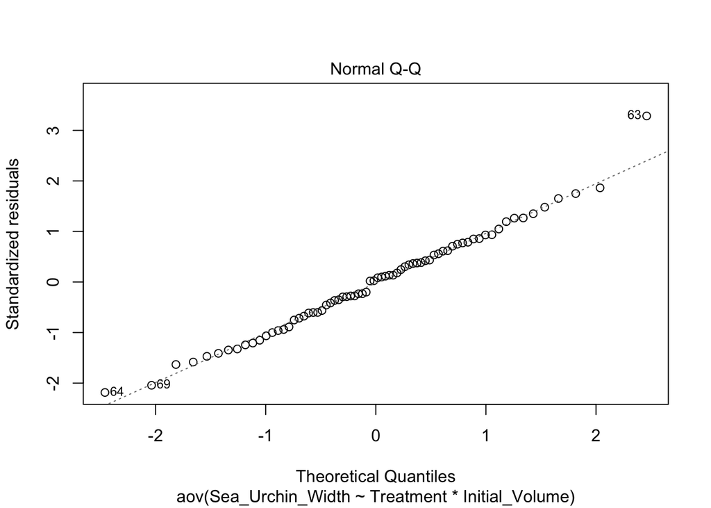

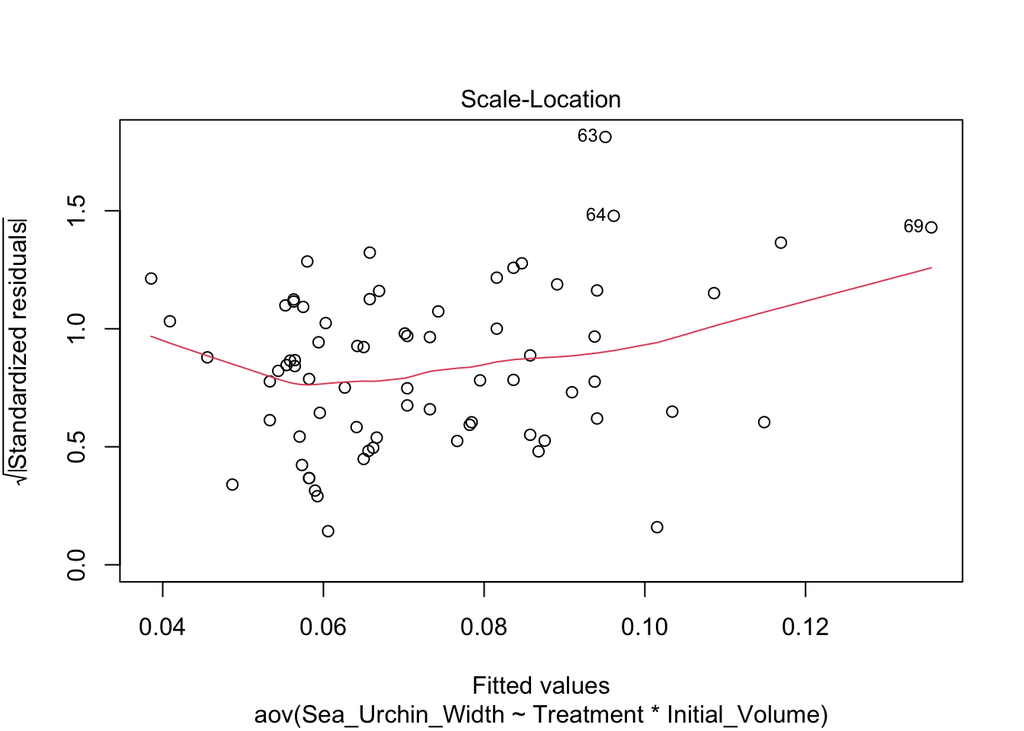

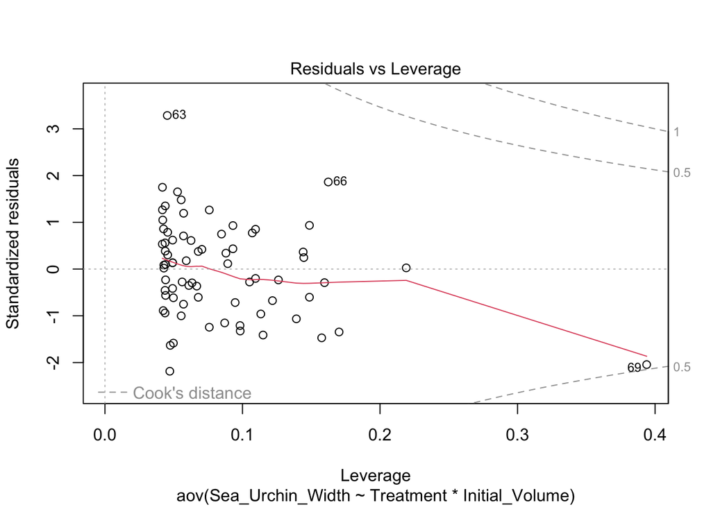

```r
par(mfrow=c(1,1)) #I am using the par() function to create multiple graphs at once
print(plot(aovTrt2))
```

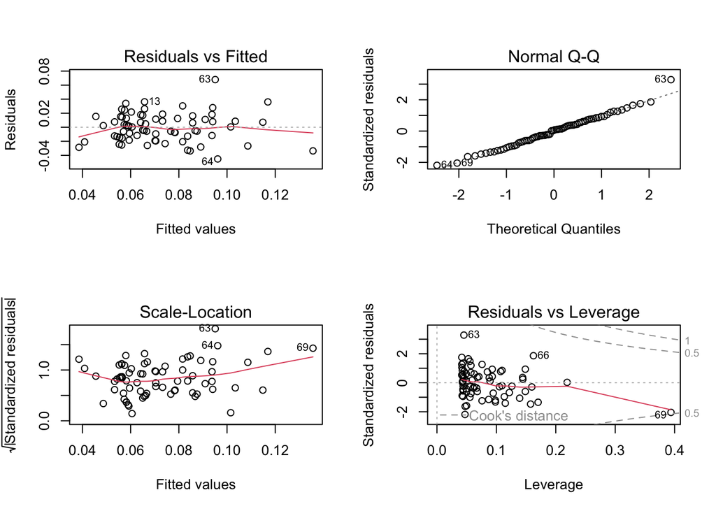

```r
lmTrt3 <- lm(Sea_Urchin_Width ~ Initial_Volume + Treatment + Initial_Volume*Treatment, data=urchin_data2)
par(mfrow=c(2,2)) #The mfrow() parameter allows to split the screen in several panels
plot(lmTrt3)
```

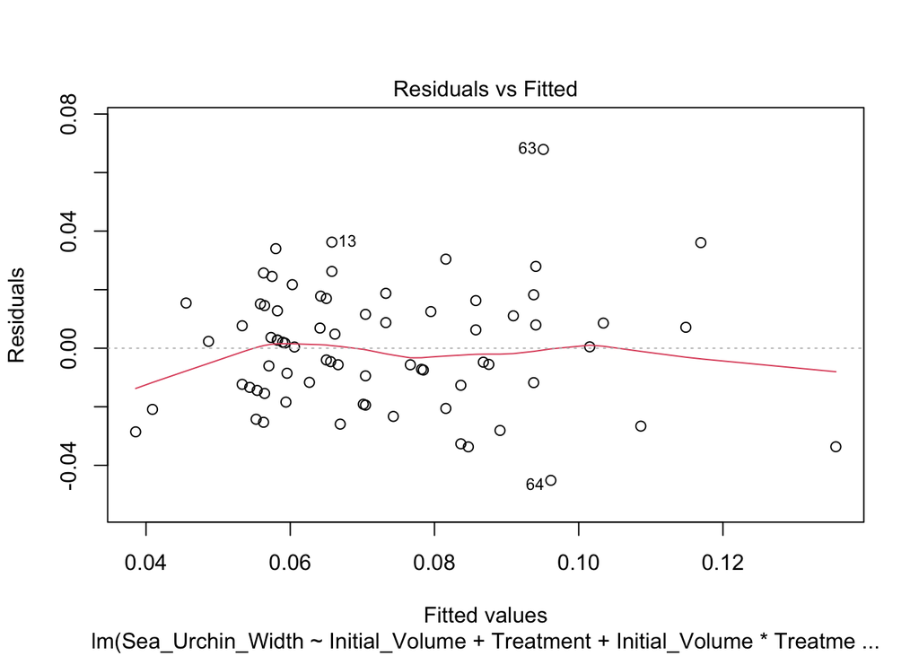

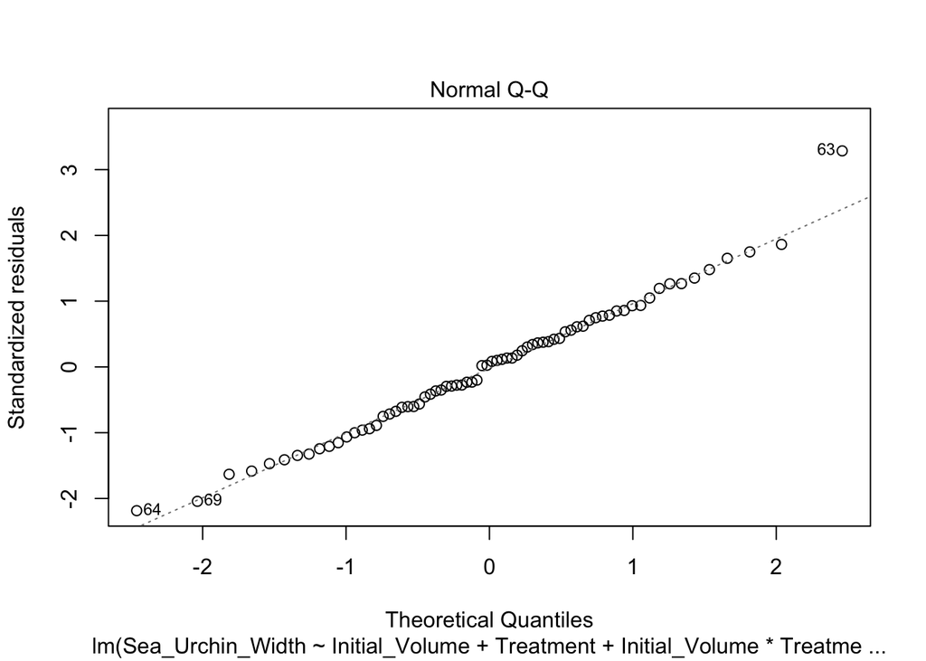

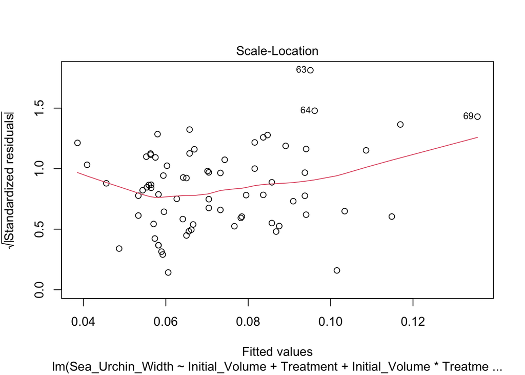

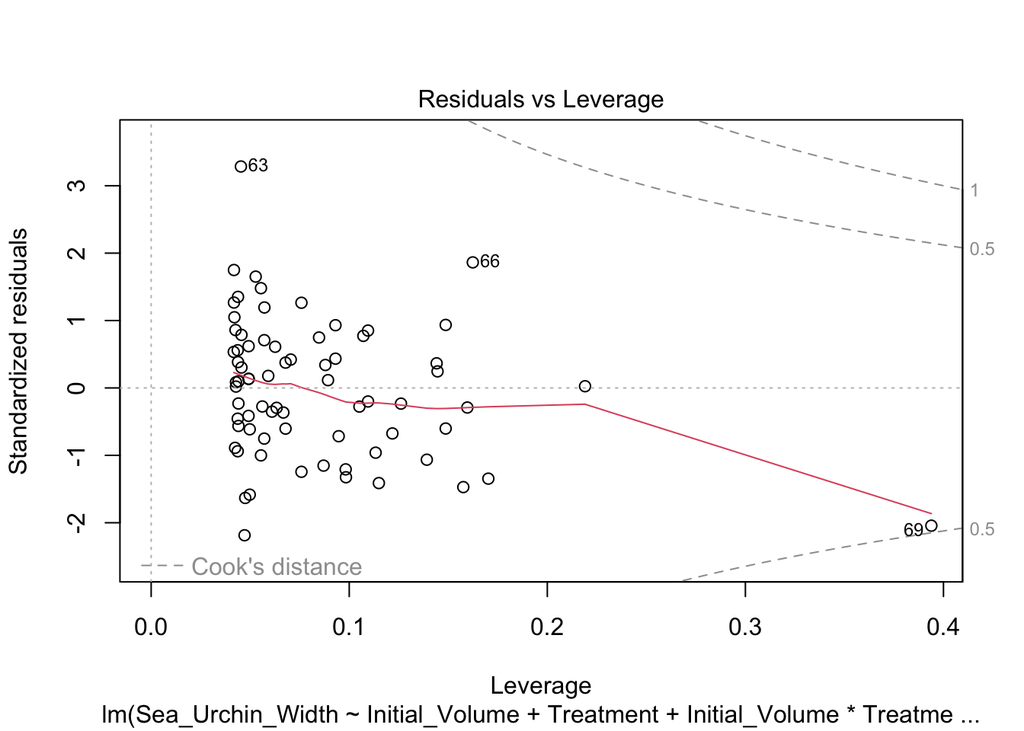

```r
par(mfrow=c(1,1)) #I am using the par() function to create multiple graphs at once
print(plot(lmTrt3))
```

**Conclusion and Interpretation of Plots**

Given data from Constable (1993), I wanted to see if there was a statistically significant relationship between sea urchin width and treatment over time. I initially loaded the data into RStudio, cleaned the data of any potential NAs, and rearranged the data set to my liking. Because I was looking at the relationship between both continuous and categorical variables, performing an ANOVA analysis seemed to be my best bet. However, this did not tell me exactly *where* significance was within the groups, so I completed Tukey’s HSD test. Here, I found that Treatment held the most significance. I then began ANOVA analyses and played around with some interactions and variables within the data set, where I found that some variable groups held more significance than others.

I also utilized the `logLike()` function to determine which pair group had the best fit for a model. I concluded that the two highest loglikelihood variables had the Treatment variable. I created and explored Residuals vs. Leverage plots to compare the groups and identify influential observations in the regression model because I was curious to see how the regression model would change if I removed observations in the data set. I discovered that I actually could not do my experiment because when looking at `Sea_Urchin_Width ~ Treatment*Initial_Volume`, there were no observations that fell outside of Cook’s distance. This shows me that there are no influential observations or points in the regression model. It also shows that if I removed some points on the data set, they will not have a large impact on the regression.

I found the same thing when I looked at `Sea_Urchin_Width ~ Initial_Volume + Treatment + Initial_Volume*Treatment`; there were no influential points on the graph. For this reason, the slope of the regression line will not be affected if I removed the points from my data set.